# Multi-cloud Performance Analysis

This experiment evalutes the performance of two multi-cloud APIs - jclouds and libclouds - compared to AWS and Azure APIs for storage service. This document summarises results of this experiment and provides R commands used to produce the analysis.

## 1. Preliminary Procedures

These procedures consists of importing the data set into the R environment, activating extras libraries, and organising data for performing analyses.

### 1.1. Importing dataset

The original dataset consists of 11 variables and 39.722 observations, organised in: - Platform; - Language; - API; - Filesize; and - Activity.

For each of these variables, it was collected: - CPU time (ms); - Memory (KB); and - Latency (ms)

```r
# Setting up current directory
setwd("~/Google Drive/Production/Empirical research/2016 - 02_06 - Performance multi-clouds/Data Analysis")

# Original data set
dataset.raw <- read.csv ("dataset.csv", header=T, sep=",")
```

> The dataset variables

```r
names (dataset.raw)
```

```
##  [1] "id"       "activity" "api"      "cputime"  "day"      "filesize"
##  [7] "language" "latency"  "memory"   "platform" "time"
```

### 1.2. Activating libraries

These are additional libraries used to specific data analysis.

```r
library ("ggplot2")     # Used for creating plots
library ("effsize")     # User for calculating Vargha-Delaney A effect size
library ("pwr")         # Used for calculating the statistical power of tests
library ("plyr")        # Used for summarising datasets
# library ("grid")        # Used to organise plots in a grid
```

### 1.3. Data reductions

```r
# https://support.speedtest.net/hc/en-us/articles/203845400-How-does-the-test-itself-work-How-is-the-result-calculated-
```

### 1.4. Creating summary dataframe

```r
dataset.summary <- ddply(
  dataset.raw,
  platform~language~api~activity~filesize,
  summarise,
  cputime_median = median(cputime),
  memory_median = median(memory),
  latency_median = median(latency)
)
```

> Summarising results

```r
dataset.summary
```

```
##    platform language        api activity filesize cputime_median
## 1       aws     java multicloud download      155          3.500
## 2       aws     java multicloud download      310          3.510
## 3       aws     java multicloud download      620          3.540
## 4       aws     java multicloud download     1240          3.590
## 5       aws     java multicloud download     2480          3.670
## 6       aws     java multicloud   upload      155          3.470
## 7       aws     java multicloud   upload      310          3.490
## 8       aws     java multicloud   upload      620          3.520
## 9       aws     java multicloud   upload     1240          3.570
## 10      aws     java multicloud   upload     2480          3.650
## 11      aws     java     native download      155          1.800
## 12      aws     java     native download      310          1.820
## 13      aws     java     native download      620          1.850
## 14      aws     java     native download     1240          1.920
```

[output cut: 147 more lines]

### 1.5. Control variables

```r
currentActivity.var <- "download"
```

### 1.6. Chart variables

```r
chart.title.cputime.performance <- "CPUTIME Performance for "
chart.title.memory.performance <- "Memory Performance for "
chart.title.latency.performance <- "Latency Performance for "

chart.title.string.activity.download <- "Download"
chart.title.string.activity.upload <- "Upload"

chart.label.axis.cputime <- "CPUTIME (ms)"
chart.label.axis.memory <- "Memory (KB)"
chart.label.axis.latency <- "Latency (ms)"
chart.label.axis.filesize <- "Filesize (KB)"
```

## 2. CPUTIME Analysis

This section performs different analysis based on the dataset.

### 2.1. Plots

> Download

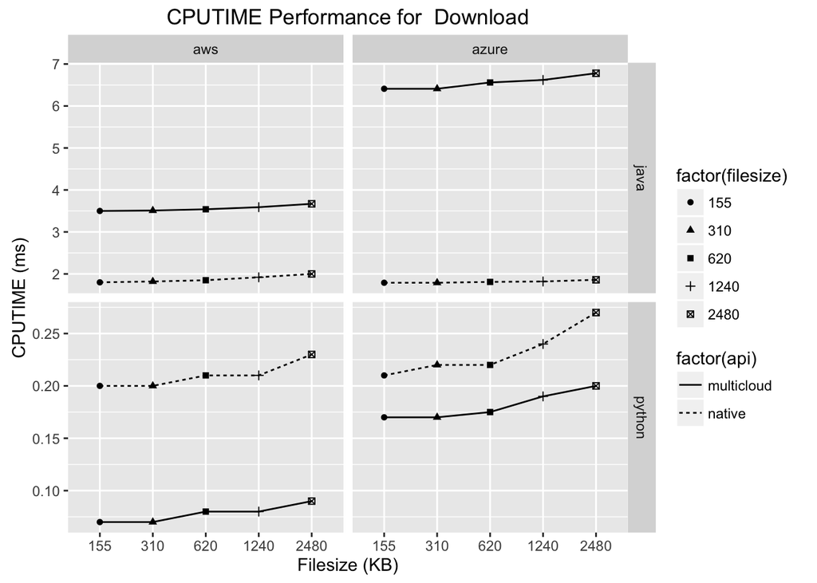

```r
ggplot(
  subset (
    dataset.summary,
    activity %in% "download"
  ),
  aes(
    y = cputime_median,
    x = factor(filesize),
    group = api
  )
) +
  geom_point(
    aes(
      shape = factor(filesize),
    )
  ) +
  geom_line(
    aes(
      linetype = factor(api)
    )
  ) +
  facet_grid(
    language ~ platform,
    scale = "free"
  ) +
  ylab (chart.label.axis.cputime) +
  xlab (chart.label.axis.filesize) +
  ggtitle (
    paste (
      chart.title.cputime.performance,
      chart.title.string.activity.download
    )
  )
```

> Upload

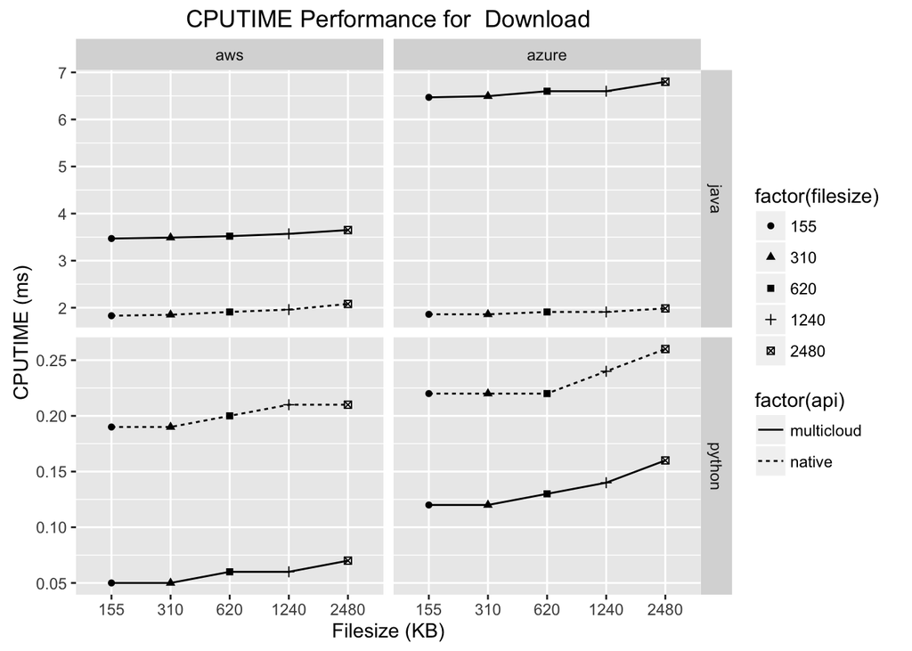

```r
ggplot(
  subset (
    dataset.summary,
    activity %in% "upload"
  ),
  aes(
    y = cputime_median,
    x = factor(filesize),
    group = api
  )
) +
  geom_point(
    aes(
      shape = factor(filesize),
    )
  ) +
  geom_line(
    aes(
      linetype = factor(api)
    )
  ) +
  facet_grid(
    language ~ platform,
    scale = "free"
  ) +
  ylab (chart.label.axis.cputime) +
  xlab (chart.label.axis.filesize) +
  ggtitle (
    paste (
      chart.title.cputime.performance,
      chart.title.string.activity.download
    )
  )
```

### 2.2. Is there any correlation between performance (cputime) and filesize?

```r
correlations.matrix <- matrix(nrow = 16, ncol = 6)

activity.var <- "download"
index <- 1

for (activity in 1:2) {
  language.var <- "java"

  for (language in 1:2) {
    platform.var <- "aws"

    for (platform in 1:2) {
      api.var <- "multicloud"

      for (api in 1:2) {
        x <- subset (
              dataset.raw,
              activity == activity.var &
              language == language.var &
              platform == platform.var &
              api == api.var
            )$cputime

        y <- subset (
              dataset.raw,
              activity == activity.var &
              language == language.var &
              platform == platform.var &
              api == api.var
            )$filesize

          cor.result <- cor.test( # Calculates spearman's correlation
            x = x,
            y = y,
            method = "spearman"
            )

          correlations.matrix[index, 1] <- activity.var
          correlations.matrix[index, 2] <- language.var
          correlations.matrix[index, 3] <- platform.var
          correlations.matrix[index, 4] <- api.var
          correlations.matrix[index, 5] <- round (cor.result$estimate, digits = 3)
          correlations.matrix[index, 6] <- cor.result$p.value
          index <- index + 1

          api.var <- "native"
      }

      platform.var <- "azure"
    }

    language.var <- "python"
  }

  activity.var <- "upload"
}

df <- as.data.frame(correlations.matrix)
names (df) <- c("Activity", "Language", "Platform", "API", "rho", "p value")
df
```

```
##    Activity Language Platform        API   rho               p value
## 1  download     java      aws multicloud 0.588 2.14389266098575e-232
## 2  download     java      aws     native 0.846                     0
## 3  download     java    azure multicloud 0.387  3.93883446868305e-90
## 4  download     java    azure     native 0.232  8.86832667565814e-32
## 5  download   python      aws multicloud 0.801                     0
## 6  download   python      aws     native 0.847                     0
## 7  download   python    azure multicloud 0.408 3.84261033660683e-101
## 8  download   python    azure     native 0.514   8.503466916233e-169
## 9    upload     java      aws multicloud 0.604 7.15997111183653e-246
## 10   upload     java      aws     native 0.892                     0
## 11   upload     java    azure multicloud 0.291  6.16378060349751e-50
## 12   upload     java    azure     native 0.343  7.34775234631932e-70
## 13   upload   python      aws multicloud 0.724                     0
## 14   upload   python      aws     native 0.804                     0
## 15   upload   python    azure multicloud 0.489 2.44670584927209e-150
## 16   upload   python    azure     native 0.427 3.11722332135295e-111
```

> Yes. The correlation is smaller for Azure than for AWS. It is likely that this difference concerns the provider rather than APIs as both APIs behaved alike.

### 2.3. Is there any difference between activities?

```r
descriptive.statistics <- matrix(nrow = 16, ncol = 11)


api.var <- "multicloud"

index <- 1

for (api in 1:2) {
  language.var <- "java"

  for (language in 1:2) {
    platform.var <- "aws"

    for (platform in 1:2) {
      activity.var <- "download"

      for (activity in 1:2) {
        dataset.temp <- subset (
              dataset.raw,
              activity == activity.var &
              language == language.var &
              platform == platform.var &
              api == api.var
            )

          quantile_result <- quantile(dataset.temp$cputime) # Calculates most descriptive statistics

          descriptive.statistics[index, 1] <- api.var
          descriptive.statistics[index, 2] <- language.var
          descriptive.statistics[index, 3] <- platform.var
          descriptive.statistics[index, 4] <- activity.var
          descriptive.statistics[index, 5] <- round(quantile_result[[1]], digits = 3) # Min
          descriptive.statistics[index, 6] <- round(quantile_result[[2]], digits = 3) # 1st Quartile
          descriptive.statistics[index, 7] <- round(quantile_result[[3]], digits = 3) # Median
          descriptive.statistics[index, 8] <- round(quantile_result[[4]], digits = 3) # 2nd Quartile
          descriptive.statistics[index, 9] <- round(quantile_result[[5]], digits = 3) # Max
          descriptive.statistics[index, 10] <- round(quantile_result[[4]] - quantile_result[[2]], digits = 3) # Inter quartile
          descriptive.statistics[index, 11] <- round(quantile_result[[5]] - quantile_result[[1]], digits = 3) # Range

          index <- index + 1

          activity.var <- "upload"
      }

      platform.var <- "azure"
    }

    language.var <- "python"
  }

  api.var <- "native"
}

df <- as.data.frame(descriptive.statistics)
names (df) <- c("API", "Language", "Platform", "Activity", "Min", "1st Q", "Median", "2nd Q", "Max", "InterQ", "Range")
df
```

```
##           API Language Platform Activity  Min 1st Q Median 2nd Q  Max
## 1  multicloud     java      aws download 3.27  3.49   3.55  3.62 3.92
## 2  multicloud     java      aws   upload 3.24  3.47   3.53   3.6 3.88
## 3  multicloud     java    azure download 5.66 6.347   6.56  6.79 8.05
## 4  multicloud     java    azure   upload 5.65  6.37   6.59  6.84 7.94
## 5  multicloud   python      aws download 0.07  0.07   0.08  0.08  0.1
## 6  multicloud   python      aws   upload 0.05  0.05   0.06  0.06 0.07
## 7  multicloud   python    azure download 0.11  0.16   0.18   0.2 0.35
## 8  multicloud   python    azure   upload 0.08  0.12   0.13  0.15 0.28
## 9      native     java      aws download 1.68  1.81   1.86  1.94 2.45
## 10     native     java      aws   upload 1.72  1.85   1.91  1.99 2.23
## 11     native     java    azure download 1.48  1.74   1.81   1.9 2.35
## 12     native     java    azure   upload 1.58  1.82    1.9     2 2.51
## 13     native   python      aws download 0.19   0.2   0.21  0.22 0.24
## 14     native   python      aws   upload 0.19   0.2    0.2  0.21 0.22
```

[output cut: 19 more lines]

> Note that there are differences for all statistics, apart from native/python/azure. Regarding the median, are these differences statistically significant?

```r
inferential.statistics <- matrix(nrow = 8, ncol = 5)

language.var <- "java"
index <- 1

  for (language in 1:2) {
    platform.var <- "aws"

    for (platform in 1:2) {
      api.var <- "multicloud"

      for (api in 1:2) {
        dataset.temp <- subset (
              dataset.raw,
              language == language.var &
              platform == platform.var &
              api == api.var
            )

          wilcox.result <- wilcox.test( # Calculates the significance test
            cputime ~ activity,
            data = dataset.temp,
            mu = 0,
            paired = FALSE,
            conf.level = 0.95
          )

          inferential.statistics[index, 1] <- language.var
          inferential.statistics[index, 2] <- platform.var
          inferential.statistics[index, 3] <- api.var
          inferential.statistics[index, 4] <- wilcox.result$p.value
          inferential.statistics[index, 5] <- wilcox.result$statistic

          index <- index + 1

          api.var <- "native"
      }

      platform.var <- "azure"
    }

    language.var <- "python"
  }

df <- as.data.frame(inferential.statistics)
names (df) <- c("Language", "Platform", "API", "p_value", "statistic")
df
```

```
##   Language Platform        API               p_value statistic
## 1     java      aws multicloud  5.84355282454907e-11   3425264
## 2     java      aws     native  1.67690559471587e-71 2162189.5
## 3     java    azure multicloud   0.00230031936679658 2969425.5
## 4     java    azure     native 2.45225761615126e-140 1838259.5
## 5   python      aws multicloud                     0 5826738.5
## 6   python      aws     native 2.15005475876629e-121 4098337.5
## 7   python    azure multicloud                     0   5591335
## 8   python    azure     native  3.10820851116098e-05 3336655.5
```

> All differences are statistically significant for alpha == 0.05. Are these differences relevant?

```r
# Calculating Vargha & Delaney A effect size

effectSize.matrix <- matrix(nrow = 8, ncol = 4)

language.var <- "java"
index <- 1

  for (language in 1:2) {
    platform.var <- "aws"

    for (platform in 1:2) {
      api.var <- "multicloud"

      for (api in 1:2) {
        dataset.temp <- subset (
              dataset.raw,
              language == language.var &
              platform == platform.var &
              api == api.var
            )

          effSize.var <- VD.A ( # Calculates the effect size
            data = dataset.temp,
            cputime ~ activity
          )

          effectSize.matrix[index, 1] <- language.var
          effectSize.matrix[index, 2] <- platform.var
          effectSize.matrix[index, 3] <- api.var
          effectSize.matrix[index, 4] <- effSize.var$estimate

          index <- index + 1

          api.var <- "native"
      }

      platform.var <- "azure"
    }

    language.var <- "python"
  }

df <- as.data.frame(effectSize.matrix)
names (df) <- c("Language", "Platform", "API", "A-Measure")
df
```

```
##   Language Platform        API         A-Measure
## 1     java      aws multicloud  0.55357802020202
## 2     java      aws     native 0.353298937908497
## 3     java    azure multicloud        0.47510808
## 4     java    azure     native        0.29412152
## 5   python      aws multicloud 0.971527886619425
## 6   python      aws     native        0.68305625
## 7   python    azure multicloud         0.8946136
## 8   python    azure     native        0.53386488
```

> According to the result above, for Java, differences are small for multicloud, but representative for native whereas for Python, differences are greater for multiclouds than native. Conclusion: for cputime, it is important to consider download and upload activities as individual activities because they consume resources differently.

### 2.4. Are differences between multicloud and native APIs relevant?

```r
significance.cputime.matrix <- matrix(nrow = 8, ncol = 5)

activity.var <- "download"
index <- 1

for (activity in 1:2) {
  language.var <- "java"

  for (language in 1:2) {
    platform.var <- "aws"

    for (platform in 1:2) {
      dataset.temp <- subset (
              dataset.raw,
              activity == activity.var &
              language == language.var &
              platform == platform.var
            )

     wilcox.result <- wilcox.test( # Calculates the statistical significance
        cputime ~ api,
        data = dataset.temp,
        mu = 0,
        paired = FALSE,
        conf.level = 0.95
      )

      significance.cputime.matrix[index, 1] <- activity.var
      significance.cputime.matrix[index, 2] <- language.var
      significance.cputime.matrix[index, 3] <- platform.var
      significance.cputime.matrix[index, 4] <- wilcox.result$p.value
      significance.cputime.matrix[index, 5] <- wilcox.result$statistic

      index <- index + 1

      platform.var <- "azure"
    }

    language.var <- "python"
  }

  activity.var <- "upload"
}

df <- as.data.frame(significance.cputime.matrix)
names (df) <- c("Activity", "Language", "Platform", "p-value", "statistic")
df
```

```
##   Activity Language Platform p-value statistic
## 1 download     java      aws       0   6250000
## 2 download     java    azure       0   6250000
## 3 download   python      aws       0         0
## 4 download   python    azure       0  518897.5
## 5   upload     java      aws       0   6058800
## 6   upload     java    azure       0   6250000
## 7   upload   python      aws       0         0
## 8   upload   python    azure       0   75561.5
```

> The Wilcoxon rank sum test shows that differences between native and multicloud APIs are statistically significant. Are these differences relevant?

```r
effsize.cputime.matrix <- matrix(nrow = 8, ncol = 4)

activity.var <- "download"
index <- 1

for (activity in 1:2) {
  language.var <- "java"

  for (language in 1:2) {
    platform.var <- "aws"

    for (platform in 1:2) {
      dataset.temp <- subset (
              dataset.raw,
              activity == activity.var &
              language == language.var &
              platform == platform.var
            )

      effSize.var <- VD.A (      # Calculates the effect size
            data = dataset.temp,
            cputime ~ api
          )

      effsize.cputime.matrix[index, 1] <- activity.var
      effsize.cputime.matrix[index, 2] <- language.var
      effsize.cputime.matrix[index, 3] <- platform.var
      effsize.cputime.matrix[index, 4] <- effSize.var$estimate

      index <- index + 1

      platform.var <- "azure"
    }

    language.var <- "python"
  }

  activity.var <- "upload"
}

df <- as.data.frame(effsize.cputime.matrix)
names (df) <- c("Activity", "Language", "Platform", "A-Measure")
df
```

```
##   Activity Language Platform  A-Measure
## 1 download     java      aws          1
## 2 download     java    azure          1
## 3 download   python      aws          0
## 4 download   python    azure  0.0830236
## 5   upload     java      aws          1
## 6   upload     java    azure          1
## 7   upload   python      aws          0
## 8   upload   python    azure 0.01208984
```

> Results above show that differences are really big. As conclusion, we can state that cputime differences between multicloud and native APIs are relevant in this experiment.

### 2.5. What is the impact of each factor on cputime?

```r
summary(
  lm (
    data = dataset.raw,
    formula = log(cputime) ~ activity + language + platform + api + filesize + day
  )
)
```

```
##
## Call:
## lm(formula = log(cputime) ~ activity + language + platform +
##     api + filesize + day, data = dataset.raw)
##
## Residuals:
##      Min       1Q   Median       3Q      Max
## -0.92823 -0.47234  0.09215  0.45755  1.07241
##
## Coefficients:
##                  Estimate Std. Error  t value Pr(>|t|)
## (Intercept)     9.392e-01  7.591e-03  123.728   <2e-16 ***
## activityupload -7.129e-02  4.748e-03  -15.016   <2e-16 ***
## languagepython -3.005e+00  4.747e-03 -632.939   <2e-16 ***
## platformazure   3.908e-01  4.748e-03   82.302   <2e-16 ***
## apinative      -9.373e-02  4.747e-03  -19.746   <2e-16 ***
## filesize        5.362e-05  2.806e-06   19.105   <2e-16 ***
## day6/25/16      2.657e-03  7.478e-03    0.355    0.722
## day6/26/16      8.449e-04  7.478e-03    0.113    0.910
## day6/27/16      5.365e-04  7.478e-03    0.072    0.943
## day6/28/16     -2.960e-03  7.549e-03   -0.392    0.695
## ---
## Signif. codes:  0 '***' 0.001 '**' 0.01 '*' 0.05 '.' 0.1 ' ' 1
##
## Residual standard error: 0.473 on 39712 degrees of freedom
## Multiple R-squared:  0.9113, Adjusted R-squared:  0.9113
## F-statistic: 4.532e+04 on 9 and 39712 DF,  p-value: < 2.2e-16
```

## 3. Memory Analysis

This section performs different analysis based on the dataset.

### 3.1. Plots

> Download

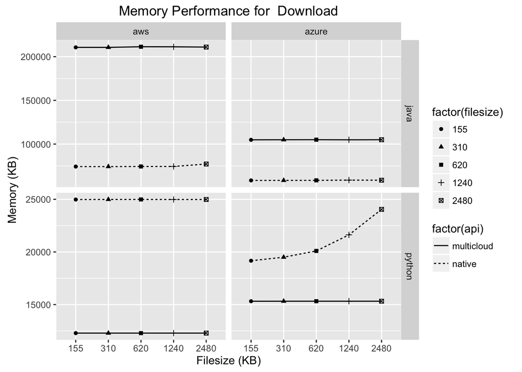

```r
ggplot(
  subset (
    dataset.summary,
    activity %in% "download"
  ),
  aes(
    y = memory_median,
    x = factor(filesize),
    group = api
  )
) +
  geom_point(
    aes(
      shape = factor(filesize),
    )
  ) +
  geom_line(
    aes(
      linetype = factor(api)
    )
  ) +
  facet_grid(
    language ~ platform,
    scale = "free"
  ) +
  ylab (chart.label.axis.memory) +
  xlab (chart.label.axis.filesize) +
  ggtitle (
    paste (
      chart.title.memory.performance,
      chart.title.string.activity.download
    )
  )
```

> Upload

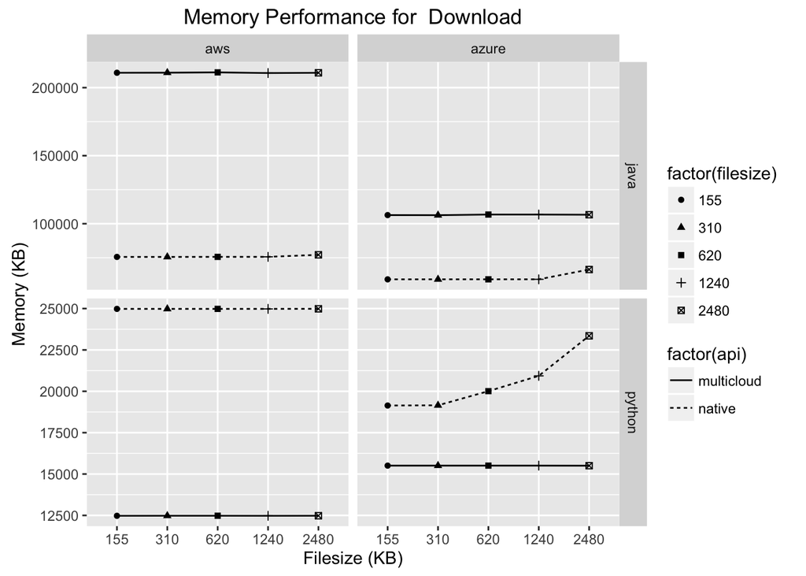

```r
ggplot(
  subset (
    dataset.summary,
    activity %in% "upload"
  ),
  aes(
    y = memory_median,
    x = factor(filesize),
    group = api
  )
) +
  geom_point(
    aes(
      shape = factor(filesize),
    )
  ) +
  geom_line(
    aes(
      linetype = factor(api)
    )
  ) +
  facet_grid(
    language ~ platform,
    scale = "free"
  ) +
  ylab (chart.label.axis.memory) +
  xlab (chart.label.axis.filesize) +
  ggtitle (
    paste (
      chart.title.memory.performance,
      chart.title.string.activity.download
    )
  )
```

> Compared with cputime, we can observe that the difference in resource consumption is greater for AWS and smaller for Azure when considering Java APIs. Both download and upload share the same result.

> As for cputime, download and upload plots seem quite similar.

### 3.2. Is there any correlation between performance (memory) and filesize?

```r
correlations.matrix <- matrix(nrow = 16, ncol = 6)

activity.var <- "download"
index <- 1

for (activity in 1:2) {
  language.var <- "java"

  for (language in 1:2) {
    platform.var <- "aws"

    for (platform in 1:2) {
      api.var <- "multicloud"

      for (api in 1:2) {
        x <- subset (
              dataset.raw,
              activity == activity.var &
              language == language.var &
              platform == platform.var &
              api == api.var
            )$memory

        y <- subset (
              dataset.raw,
              activity == activity.var &
              language == language.var &
              platform == platform.var &
              api == api.var
            )$filesize

          cor.result <- cor.test( # Calculates spearman's correlation
            x = x,
            y = y,
            method = "spearman"
            )

          correlations.matrix[index, 1] <- activity.var
          correlations.matrix[index, 2] <- language.var
          correlations.matrix[index, 3] <- platform.var
          correlations.matrix[index, 4] <- api.var
          correlations.matrix[index, 5] <- round (cor.result$estimate, digits = 3)
          correlations.matrix[index, 6] <- cor.result$p.value
          index <- index + 1

          api.var <- "native"
      }

      platform.var <- "azure"
    }

    language.var <- "python"
  }

  activity.var <- "upload"
}

df <- as.data.frame(correlations.matrix)
names (df) <- c("Activity", "Language", "Platform", "API", "rho", "p value")
df
```

```
##    Activity Language Platform        API    rho               p value
## 1  download     java      aws multicloud  0.053   0.00778896124698192
## 2  download     java      aws     native  0.369  2.22872665923899e-81
## 3  download     java    azure multicloud  0.026     0.201001021054526
## 4  download     java    azure     native  0.255  1.79191474227841e-38
## 5  download   python      aws multicloud   0.03      0.13482422131111
## 6  download   python      aws     native  0.096  1.59168250014596e-06
## 7  download   python    azure multicloud   0.02     0.322957507624462
## 8  download   python    azure     native   0.98                     0
## 9    upload     java      aws multicloud      0     0.984764558726865
## 10   upload     java      aws     native  0.261  1.89871516525152e-39
## 11   upload     java    azure multicloud  0.099  6.47955363945659e-07
## 12   upload     java    azure     native  0.468 3.37009448405592e-136
## 13   upload   python      aws multicloud   0.11  5.87815595309479e-08
## 14   upload   python      aws     native   0.27  2.07884328227668e-41
## 15   upload   python    azure multicloud -0.034    0.0908492542734032
## 16   upload   python    azure     native  0.938                     0
```

> Yes, but correlations are smaller than those calculated for cputime, overall. Whereas for cputime the correlation is smaller for Azure than for AWS, the correlation is greater for Azure than for AWS, for memory.

### 3.3. Is there any difference between activities?

```r
descriptive.statistics <- matrix(nrow = 16, ncol = 11)


api.var <- "multicloud"

index <- 1

for (api in 1:2) {
  language.var <- "java"

  for (language in 1:2) {
    platform.var <- "aws"

    for (platform in 1:2) {
      activity.var <- "download"

      for (activity in 1:2) {
        dataset.temp <- subset (
              dataset.raw,
              activity == activity.var &
              language == language.var &
              platform == platform.var &
              api == api.var
            )

          quantile_result <- quantile(dataset.temp$memory) # Calculates most descriptive statistics

          descriptive.statistics[index, 1] <- api.var
          descriptive.statistics[index, 2] <- language.var
          descriptive.statistics[index, 3] <- platform.var
          descriptive.statistics[index, 4] <- activity.var
          descriptive.statistics[index, 5] <- round(quantile_result[[1]], digits = 3) # Min
          descriptive.statistics[index, 6] <- round(quantile_result[[2]], digits = 3) # 1st Quartile
          descriptive.statistics[index, 7] <- round(quantile_result[[3]], digits = 3) # Median
          descriptive.statistics[index, 8] <- round(quantile_result[[4]], digits = 3) # 2nd Quartile
          descriptive.statistics[index, 9] <- round(quantile_result[[5]], digits = 3) # Max
          descriptive.statistics[index, 10] <- round(quantile_result[[4]] - quantile_result[[2]], digits = 3) # Inter quartile
          descriptive.statistics[index, 11] <- round(quantile_result[[5]] - quantile_result[[1]], digits = 3) # Range

          index <- index + 1

          activity.var <- "upload"
      }

      platform.var <- "azure"
    }

    language.var <- "python"
  }

  api.var <- "native"
}

df <- as.data.frame(descriptive.statistics)
names (df) <- c("API", "Language", "Platform", "Activity", "Min", "1st Q", "Median", "2nd Q", "Max", "InterQ", "Range")
df
```

```
##           API Language Platform Activity    Min  1st Q Median  2nd Q
## 1  multicloud     java      aws download 201164 208715 210922 214452
## 2  multicloud     java      aws   upload 201760 208692 210948 214348
## 3  multicloud     java    azure download  90652 102788 104938 105469
## 4  multicloud     java    azure   upload  90912 105555 106558 109160
## 5  multicloud   python      aws download  12284  12288  12288  12292
## 6  multicloud   python      aws   upload  12472  12476  12480  12484
## 7  multicloud   python    azure download  15164  15268  15320  15364
## 8  multicloud   python    azure   upload  15352  15456  15508  15552
## 9      native     java      aws download  70164  73708  74536  75852
## 10     native     java      aws   upload  71104  74888  75826  77088
## 11     native     java    azure download  56900  58308  58568  58829
## 12     native     java    azure   upload  57736  58964  59236  65365
## 13     native   python      aws download  24976  24984  24988  24988
## 14     native   python      aws   upload  24968  24976  24980  24984
```

[output cut: 19 more lines]

> As for cputime, there are differences for all statistics. Regarding the median, are these differences statistically significant?

```r
inferential.statistics <- matrix(nrow = 8, ncol = 5)

language.var <- "java"
index <- 1

  for (language in 1:2) {
    platform.var <- "aws"

    for (platform in 1:2) {
      api.var <- "multicloud"

      for (api in 1:2) {
        dataset.temp <- subset (
              dataset.raw,
              language == language.var &
              platform == platform.var &
              api == api.var
            )

          wilcox.result <- wilcox.test( # Calculates the significance test
            memory ~ activity,
            data = dataset.temp,
            mu = 0,
            paired = FALSE,
            conf.level = 0.95
          )

          inferential.statistics[index, 1] <- language.var
          inferential.statistics[index, 2] <- platform.var
          inferential.statistics[index, 3] <- api.var
          inferential.statistics[index, 4] <- wilcox.result$p.value
          inferential.statistics[index, 5] <- wilcox.result$statistic

          index <- index + 1

          api.var <- "native"
      }

      platform.var <- "azure"
    }

    language.var <- "python"
  }

df <- as.data.frame(inferential.statistics)
names (df) <- c("Language", "Platform", "API", "p_value", "statistic")
df
```

```
##   Language Platform        API               p_value statistic
## 1     java      aws multicloud     0.206287966110848   3157768
## 2     java      aws     native 1.13314436808293e-111 1931855.5
## 3     java    azure multicloud  2.0114037783032e-285   1282426
## 4     java    azure     native                     0  990959.5
## 5   python      aws multicloud                     0         0
## 6   python      aws     native                     0 5067531.5
## 7   python    azure multicloud                     0     29883
## 8   python    azure     native   2.3055477080431e-37 3776897.5
```

> All differences are statistically significant for alpha == 0.05, apart from Java/AWS/Multicloud. Are these differences relevant?

```r
# Calculating Vargha & Delaney A effect size

effectSize.matrix <- matrix(nrow = 8, ncol = 4)

language.var <- "java"
index <- 1

  for (language in 1:2) {
    platform.var <- "aws"

    for (platform in 1:2) {
      api.var <- "multicloud"

      for (api in 1:2) {
        dataset.temp <- subset (
              dataset.raw,
              language == language.var &
              platform == platform.var &
              api == api.var
            )

          effSize.var <- VD.A ( # Calculates the effect size
            data = dataset.temp,
            memory ~ activity
          )

          effectSize.matrix[index, 1] <- language.var
          effectSize.matrix[index, 2] <- platform.var
          effectSize.matrix[index, 3] <- api.var
          effectSize.matrix[index, 4] <- effSize.var$estimate

          index <- index + 1

          api.var <- "native"
      }

      platform.var <- "azure"
    }

    language.var <- "python"
  }

df <- as.data.frame(effectSize.matrix)
names (df) <- c("Language", "Platform", "API", "A-Measure")
df
```

```
##   Language Platform        API         A-Measure
## 1     java      aws multicloud 0.510346343434343
## 2     java      aws     native 0.315662663398693
## 3     java    azure multicloud        0.20518816
## 4     java    azure     native        0.15855352
## 5   python      aws multicloud                 0
## 6   python      aws     native 0.844588583333333
## 7   python    azure multicloud        0.00478128
## 8   python    azure     native         0.6043036
```

> Different from cputime, all differences are largely representative, apart from Java/AWS/Multicloud. Conclusion: as for cputime, it is important to consider download and upload activities as individual activities because they consume resources differently.

### 3.4. Are differences between multicloud and native APIs relevant?

```r
significance.cputime.matrix <- matrix(nrow = 8, ncol = 5)

activity.var <- "download"
index <- 1

for (activity in 1:2) {
  language.var <- "java"

  for (language in 1:2) {
    platform.var <- "aws"

    for (platform in 1:2) {
      dataset.temp <- subset (
              dataset.raw,
              activity == activity.var &
              language == language.var &
              platform == platform.var
            )

     wilcox.result <- wilcox.test( # Calculates the statistical significance
        memory ~ api,
        data = dataset.temp,
        mu = 0,
        paired = FALSE,
        conf.level = 0.95
      )

      significance.cputime.matrix[index, 1] <- activity.var
      significance.cputime.matrix[index, 2] <- language.var
      significance.cputime.matrix[index, 3] <- platform.var
      significance.cputime.matrix[index, 4] <- wilcox.result$p.value
      significance.cputime.matrix[index, 5] <- wilcox.result$statistic

      index <- index + 1

      platform.var <- "azure"
    }

    language.var <- "python"
  }

  activity.var <- "upload"
}

df <- as.data.frame(significance.cputime.matrix)
names (df) <- c("Activity", "Language", "Platform", "p-value", "statistic")
df
```

```
##   Activity Language Platform p-value statistic
## 1 download     java      aws       0   6250000
## 2 download     java    azure       0   6250000
## 3 download   python      aws       0         0
## 4 download   python    azure       0         0
## 5   upload     java      aws       0   6058800
## 6   upload     java    azure       0   6250000
## 7   upload   python      aws       0         0
## 8   upload   python    azure       0         0
```

> The Wilcoxon rank sum test shows that differences between native and multicloud APIs are statistically significant, like for cputime. Are these differences relevant?

```r
effsize.cputime.matrix <- matrix(nrow = 8, ncol = 4)

activity.var <- "download"
index <- 1

for (activity in 1:2) {
  language.var <- "java"

  for (language in 1:2) {
    platform.var <- "aws"

    for (platform in 1:2) {
      dataset.temp <- subset (
              dataset.raw,
              activity == activity.var &
              language == language.var &
              platform == platform.var
            )

      effSize.var <- VD.A (      # Calculates the effect size
            data = dataset.temp,
            memory ~ api
          )

      effsize.cputime.matrix[index, 1] <- activity.var
      effsize.cputime.matrix[index, 2] <- language.var
      effsize.cputime.matrix[index, 3] <- platform.var
      effsize.cputime.matrix[index, 4] <- effSize.var$estimate

      index <- index + 1

      platform.var <- "azure"
    }

    language.var <- "python"
  }

  activity.var <- "upload"
}

df <- as.data.frame(effsize.cputime.matrix)
names (df) <- c("Activity", "Language", "Platform", "A-Measure")
df
```

```
##   Activity Language Platform A-Measure
## 1 download     java      aws         1
## 2 download     java    azure         1
## 3 download   python      aws         0
## 4 download   python    azure         0
## 5   upload     java      aws         1
## 6   upload     java    azure         1
## 7   upload   python      aws         0
## 8   upload   python    azure         0
```

> Results above show that differences are really big, like for cputime. As conclusion, we can state that memory differences between multicloud and native APIs are relevant in this experiment.

### 3.5. What is the impact of each factor on memory?

```r
summary(
  lm (
    data = dataset.raw,
    formula = log(memory) ~ activity + language + platform + api + filesize + day
  )
)
```

```
##
## Call:
## lm(formula = log(memory) ~ activity + language + platform + api +
##     filesize + day, data = dataset.raw)
##
## Residuals:
##      Min       1Q   Median       3Q      Max
## -0.57630 -0.33099 -0.05083  0.31027  0.61024
##
## Coefficients:
##                  Estimate Std. Error  t value Pr(>|t|)
## (Intercept)     1.168e+01  5.820e-03 2007.387  < 2e-16 ***
## activityupload  1.101e-02  3.640e-03    3.025  0.00248 **
## languagepython -1.732e+00  3.639e-03 -475.917  < 2e-16 ***
## platformazure  -2.247e-01  3.640e-03  -61.726  < 2e-16 ***
## apinative      -1.524e-01  3.639e-03  -41.866  < 2e-16 ***
## filesize        1.577e-05  2.152e-06    7.331 2.33e-13 ***
## day6/25/16      3.145e-04  5.733e-03    0.055  0.95625
## day6/26/16      8.381e-05  5.733e-03    0.015  0.98834
## day6/27/16      8.536e-05  5.733e-03    0.015  0.98812
## day6/28/16      3.066e-03  5.787e-03    0.530  0.59630
## ---
## Signif. codes:  0 '***' 0.001 '**' 0.01 '*' 0.05 '.' 0.1 ' ' 1
##
## Residual standard error: 0.3626 on 39712 degrees of freedom
## Multiple R-squared:  0.854,  Adjusted R-squared:  0.854
## F-statistic: 2.582e+04 on 9 and 39712 DF,  p-value: < 2.2e-16
```

> Together, the six factors explain about 85% of memory variation (less than the cputime, 91%). All factors are representative at alpha = 0.01, apart from the trials. As trials are not representative, we can conclude that results would be the same regardless of the day of the week.

## 4. Latency Analysis

This section performs different analysis based on the dataset.

### 4.1. Plots

> Download

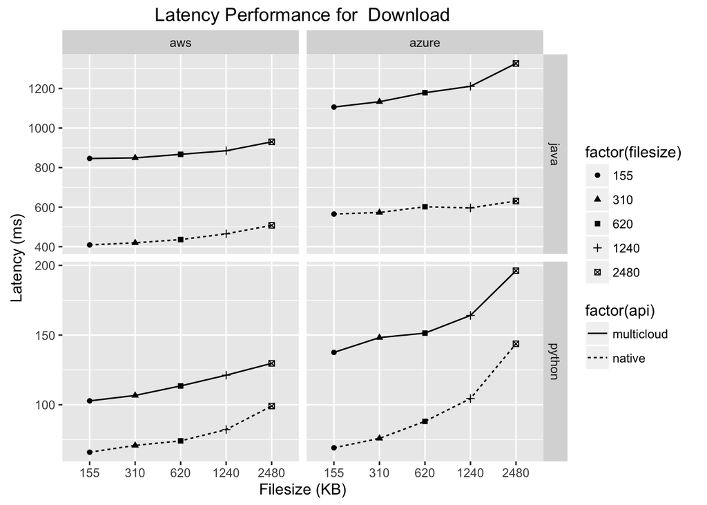

```r
ggplot(
  subset (
    dataset.summary,
    activity %in% "download"
  ),
  aes(
    y = latency_median,
    x = factor(filesize),
    group = api
  )
) +
  geom_point(
    aes(
      shape = factor(filesize),
    )
  ) +
  geom_line(
    aes(
      linetype = factor(api)
    )
  ) +
  facet_grid(
    language ~ platform,
    scale = "free"
  ) +
  ylab (chart.label.axis.latency) +
  xlab (chart.label.axis.filesize) +
  ggtitle (
    paste (
      chart.title.latency.performance,
      chart.title.string.activity.download
    )
  )
```

> Upload

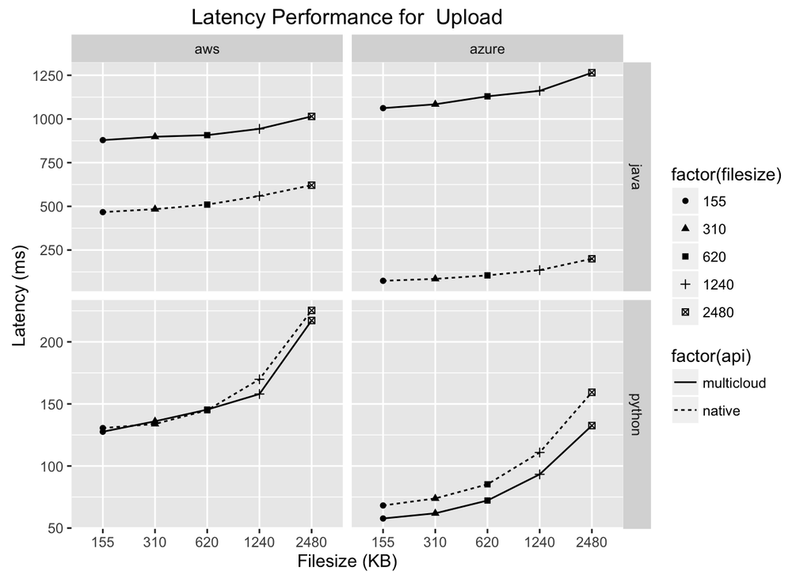

```r
ggplot(
  subset (
    dataset.summary,
    activity %in% "upload"
  ),
  aes(
    y = latency_median,
    x = factor(filesize),
    group = api
  )
) +
  geom_point(
    aes(
      shape = factor(filesize),
    )
  ) +
  geom_line(
    aes(
      linetype = factor(api)
    )
  ) +
  facet_grid(
    language ~ platform,
    scale = "free"
  ) +
  ylab (chart.label.axis.latency) +
  xlab (chart.label.axis.filesize) +
  ggtitle (
    paste (
      chart.title.latency.performance,
      chart.title.string.activity.upload
    )
  )
```

> Unlike the other two performance indicators, latency was always greater for multicloud than native APIs, apart from upload using Python APIs. The correlation between filesize and latency seems more evident for latency than for the other two performance indicators.

> It is worth to note that in our first experiment, we looked at the uppper part of first plot only.

### 4.2. Is there any correlation between performance (latency) and filesize?

```r
correlations.matrix <- matrix(nrow = 16, ncol = 6)

activity.var <- "download"
index <- 1

for (activity in 1:2) {
  language.var <- "java"

  for (language in 1:2) {
    platform.var <- "aws"

    for (platform in 1:2) {
      api.var <- "multicloud"

      for (api in 1:2) {
        x <- subset (
              dataset.raw,
              activity == activity.var &
              language == language.var &
              platform == platform.var &
              api == api.var
            )$latency

        y <- subset (
              dataset.raw,
              activity == activity.var &
              language == language.var &
              platform == platform.var &
              api == api.var
            )$filesize

          cor.result <- cor.test( # Calculates spearman's correlation
            x = x,
            y = y,
            method = "spearman"
            )

          correlations.matrix[index, 1] <- activity.var
          correlations.matrix[index, 2] <- language.var
          correlations.matrix[index, 3] <- platform.var
          correlations.matrix[index, 4] <- api.var
          correlations.matrix[index, 5] <- round (cor.result$estimate, digits = 3)
          correlations.matrix[index, 6] <- cor.result$p.value
          index <- index + 1

          api.var <- "native"
      }

      platform.var <- "azure"
    }

    language.var <- "python"
  }

  activity.var <- "upload"
}

df <- as.data.frame(correlations.matrix)
names (df) <- c("Activity", "Language", "Platform", "API", "rho", "p value")
df
```

```
##    Activity Language Platform        API   rho               p value
## 1  download     java      aws multicloud 0.466 3.26410706722302e-135
## 2  download     java      aws     native  0.81                     0
## 3  download     java    azure multicloud 0.561  5.8111617156979e-207
## 4  download     java    azure     native 0.353  4.05682809375654e-74
## 5  download   python      aws multicloud 0.425 4.03057336761366e-110
## 6  download   python      aws     native 0.617 1.00573646894416e-261
## 7  download   python    azure multicloud  0.53 3.11060853420967e-181
## 8  download   python    azure     native 0.744                     0
## 9    upload     java      aws multicloud 0.487 1.49519169046997e-147
## 10   upload     java      aws     native 0.742                     0
## 11   upload     java    azure multicloud 0.564 1.20664024579202e-209
## 12   upload     java    azure     native 0.834                     0
## 13   upload   python      aws multicloud 0.507 1.22205343437697e-156
## 14   upload   python      aws     native 0.559 3.09269115016346e-197
## 15   upload   python    azure multicloud 0.742                     0
## 16   upload   python    azure     native  0.81                     0
```

> Yes. Overall, correlations are medium or large. It seems that the correlations is greater for native than for multicloud APIs.

### 4.3. Is there any difference between activities?

```r
descriptive.statistics <- matrix(nrow = 16, ncol = 11)


api.var <- "multicloud"

index <- 1

for (api in 1:2) {
  language.var <- "java"

  for (language in 1:2) {
    platform.var <- "aws"

    for (platform in 1:2) {
      activity.var <- "download"

      for (activity in 1:2) {
        dataset.temp <- subset (
              dataset.raw,
              activity == activity.var &
              language == language.var &
              platform == platform.var &
              api == api.var
            )

          quantile_result <- quantile(dataset.temp$latency) # Calculates most descriptive statistics

          descriptive.statistics[index, 1] <- api.var
          descriptive.statistics[index, 2] <- language.var
          descriptive.statistics[index, 3] <- platform.var
          descriptive.statistics[index, 4] <- activity.var
          descriptive.statistics[index, 5] <- round(quantile_result[[1]], digits = 3) # Min
          descriptive.statistics[index, 6] <- round(quantile_result[[2]], digits = 3) # 1st Quartile
          descriptive.statistics[index, 7] <- round(quantile_result[[3]], digits = 3) # Median
          descriptive.statistics[index, 8] <- round(quantile_result[[4]], digits = 3) # 2nd Quartile
          descriptive.statistics[index, 9] <- round(quantile_result[[5]], digits = 3) # Max
          descriptive.statistics[index, 10] <- round(quantile_result[[4]] - quantile_result[[2]], digits = 3) # Inter quartile
          descriptive.statistics[index, 11] <- round(quantile_result[[5]] - quantile_result[[1]], digits = 3) # Range

          index <- index + 1

          activity.var <- "upload"
      }

      platform.var <- "azure"
    }

    language.var <- "python"
  }

  api.var <- "native"
}

df <- as.data.frame(descriptive.statistics)
names (df) <- c("API", "Language", "Platform", "Activity", "Min", "1st Q", "Median", "2nd Q", "Max", "InterQ", "Range")
df
```

```
##           API Language Platform Activity    Min   1st Q  Median   2nd Q
## 1  multicloud     java      aws download    674     833     869     915
## 2  multicloud     java      aws   upload    675     872     926     994
## 3  multicloud     java    azure download    895    1108    1190    1286
## 4  multicloud     java    azure   upload    851    1061    1141    1226
## 5  multicloud   python      aws download 67.698 101.285 114.278 131.879
## 6  multicloud   python      aws   upload 48.246 122.923 155.628 197.829
## 7  multicloud   python    azure download 99.458 140.205 160.049 191.724
## 8  multicloud   python    azure   upload   37.9  61.026  81.387 117.974
## 9      native     java      aws download    360     416     442     480
## 10     native     java      aws   upload    380     479     524     590
## 11     native     java    azure download    448     554     593     635
## 12     native     java    azure   upload     49      84     112  165.25
## 13     native   python      aws download 46.306  67.428  77.161  90.256
## 14     native   python      aws   upload 58.552 127.102 159.089 205.676
```

[output cut: 19 more lines]

> As for previous performance indicators, there are differences for all statistics. Regarding the median, are these differences statistically significant?

```r
inferential.statistics <- matrix(nrow = 8, ncol = 5)

language.var <- "java"
index <- 1

  for (language in 1:2) {
    platform.var <- "aws"

    for (platform in 1:2) {
      api.var <- "multicloud"

      for (api in 1:2) {
        dataset.temp <- subset (
              dataset.raw,
              language == language.var &
              platform == platform.var &
              api == api.var
            )

          wilcox.result <- wilcox.test( # Calculates the significance test
            latency ~ activity,
            data = dataset.temp,
            mu = 0,
            paired = FALSE,
            conf.level = 0.95
          )

          inferential.statistics[index, 1] <- language.var
          inferential.statistics[index, 2] <- platform.var
          inferential.statistics[index, 3] <- api.var
          inferential.statistics[index, 4] <- wilcox.result$p.value
          inferential.statistics[index, 5] <- wilcox.result$statistic

          index <- index + 1

          api.var <- "native"
      }

      platform.var <- "azure"
    }

    language.var <- "python"
  }

df <- as.data.frame(inferential.statistics)
names (df) <- c("Language", "Platform", "API", "p_value", "statistic")
df
```

```
##   Language Platform        API               p_value statistic
## 1     java      aws multicloud 4.26842312924171e-129   1869314
## 2     java      aws     native                     0    965781
## 3     java    azure multicloud  2.55207629298194e-46   3854268
## 4     java    azure     native                     0 6242657.5
## 5   python      aws multicloud 4.20529487158932e-231 1392505.5
## 6   python      aws     native                     0  319132.5
## 7   python    azure multicloud                     0 5739369.5
## 8   python    azure     native      0.69540087760451   3144983
```

> All differences are statistically significant for alpha == 0.05, apart from Python/Azure/Native. Are these differences relevant?

```r
# Calculating Vargha & Delaney A effect size

effectSize.matrix <- matrix(nrow = 8, ncol = 4)

language.var <- "java"
index <- 1

  for (language in 1:2) {
    platform.var <- "aws"

    for (platform in 1:2) {
      api.var <- "multicloud"

      for (api in 1:2) {
        dataset.temp <- subset (
              dataset.raw,
              language == language.var &
              platform == platform.var &
              api == api.var
            )

          effSize.var <- VD.A ( # Calculates the effect size
            data = dataset.temp,
            latency ~ activity
          )

          effectSize.matrix[index, 1] <- language.var
          effectSize.matrix[index, 2] <- platform.var
          effectSize.matrix[index, 3] <- api.var
          effectSize.matrix[index, 4] <- effSize.var$estimate

          index <- index + 1

          api.var <- "native"
      }

      platform.var <- "azure"
    }

    language.var <- "python"
  }

df <- as.data.frame(effectSize.matrix)
names (df) <- c("Language", "Platform", "API", "A-Measure")
df
```

```
##   Language Platform        API         A-Measure
## 1     java      aws multicloud 0.302111353535354
## 2     java      aws     native 0.157807352941176
## 3     java    azure multicloud        0.61668288
## 4     java    azure     native         0.9988252
## 5   python      aws multicloud 0.232180992080033
## 6   python      aws     native        0.05318875
## 7   python    azure multicloud        0.91829912
## 8   python    azure     native        0.50319728
```

> Like memory, all differences are largely representative, apart from Python/Azure/Native Conclusion: for all performance indictors is important to consider download and upload activities as individual activities because they consume resources differently.

### 4.4. Are differences between multicloud and native APIs relevant?

```r
significance.cputime.matrix <- matrix(nrow = 8, ncol = 5)

activity.var <- "download"
index <- 1

for (activity in 1:2) {
  language.var <- "java"

  for (language in 1:2) {
    platform.var <- "aws"

    for (platform in 1:2) {
      dataset.temp <- subset (
              dataset.raw,
              activity == activity.var &
              language == language.var &
              platform == platform.var
            )

     wilcox.result <- wilcox.test( # Calculates the statistical significance
        latency ~ api,
        data = dataset.temp,
        mu = 0,
        paired = FALSE,
        conf.level = 0.95
      )

      significance.cputime.matrix[index, 1] <- activity.var
      significance.cputime.matrix[index, 2] <- language.var
      significance.cputime.matrix[index, 3] <- platform.var
      significance.cputime.matrix[index, 4] <- wilcox.result$p.value
      significance.cputime.matrix[index, 5] <- wilcox.result$statistic

      index <- index + 1

      platform.var <- "azure"
    }

    language.var <- "python"
  }

  activity.var <- "upload"
}

df <- as.data.frame(significance.cputime.matrix)
names (df) <- c("Activity", "Language", "Platform", "p-value", "statistic")
df
```

```
##   Activity Language Platform              p-value statistic
## 1 download     java      aws                    0   6223584
## 2 download     java    azure                    0   6201589
## 3 download   python      aws                    0 5556240.5
## 4 download   python    azure                    0   5495269
## 5   upload     java      aws                    0 6012986.5
## 6   upload     java    azure                    0   6245704
## 7   upload   python      aws  0.00179230368801949 2728943.5
## 8   upload   python    azure 1.40814792563647e-43 2418521.5
```

```r
effsize.cputime.matrix <- matrix(nrow = 8, ncol = 4)

activity.var <- "download"
index <- 1

for (activity in 1:2) {
  language.var <- "java"

  for (language in 1:2) {
    platform.var <- "aws"

    for (platform in 1:2) {
      dataset.temp <- subset (
              dataset.raw,
              activity == activity.var &
              language == language.var &
              platform == platform.var
            )

      effSize.var <- VD.A (      # Calculates the effect size
            data = dataset.temp,
            latency ~ api
          )

      effsize.cputime.matrix[index, 1] <- activity.var
      effsize.cputime.matrix[index, 2] <- language.var
      effsize.cputime.matrix[index, 3] <- platform.var
      effsize.cputime.matrix[index, 4] <- effSize.var$estimate

      index <- index + 1

      platform.var <- "azure"
    }

    language.var <- "python"
  }

  activity.var <- "upload"
}

df <- as.data.frame(effsize.cputime.matrix)
names (df) <- c("Activity", "Language", "Platform", "A-Measure")
df
```

```
##   Activity Language Platform         A-Measure
## 1 download     java      aws        0.99577344
## 2 download     java    azure        0.99225424
## 3 download   python      aws        0.88899848
## 4 download   python    azure        0.87924304
## 5   upload     java      aws 0.992438519178715
## 6   upload     java    azure        0.99931264
## 7   upload   python      aws 0.473972401695151
## 8   upload   python    azure        0.38696344
```

> Results above show that differences are really big, except for upload/python/aws. As conclusion, we can state that latency differences between multicloud and native APIs are relevant in this experiment (like cputime and memory).

### 4.5. What is the impact of each factor on latency?

```r
summary(
  lm (
    data = dataset.raw,
    formula = log(latency) ~ activity + language + platform + api + filesize + day
  )
)
```

```
##
## Call:
## lm(formula = log(latency) ~ activity + language + platform +
##     api + filesize + day, data = dataset.raw)
##
## Residuals:
##     Min      1Q  Median      3Q     Max
## -1.9215 -0.2240  0.0420  0.3077  4.3712
##
## Coefficients:
##                  Estimate Std. Error  t value Pr(>|t|)
## (Intercept)     6.699e+00  8.032e-03  833.999   <2e-16 ***
## activityupload -1.472e-01  5.024e-03  -29.298   <2e-16 ***
## languagepython -1.661e+00  5.023e-03 -330.703   <2e-16 ***
## platformazure  -1.426e-01  5.024e-03  -28.377   <2e-16 ***
## apinative      -6.227e-01  5.023e-03 -123.972   <2e-16 ***
## filesize        1.739e-04  2.969e-06   58.571   <2e-16 ***
## day6/25/16      7.314e-04  7.913e-03    0.092   0.9264
## day6/26/16      1.992e-02  7.913e-03    2.517   0.0118 *
## day6/27/16      1.252e-02  7.913e-03    1.582   0.1136
## day6/28/16      1.939e-02  7.987e-03    2.428   0.0152 *
## ---
## Signif. codes:  0 '***' 0.001 '**' 0.01 '*' 0.05 '.' 0.1 ' ' 1
##
## Residual standard error: 0.5005 on 39712 degrees of freedom
## Multiple R-squared:  0.7657, Adjusted R-squared:  0.7657
## F-statistic: 1.442e+04 on 9 and 39712 DF,  p-value: < 2.2e-16
```

## 5. Hypothesis test

This section performs different analysis based on the dataset.

### 5.1. CPUTIME

```r
wilcox.matrix <- matrix(nrow = 40, ncol = 6)

activity.var <- "download"
filesize.vector <- c(155, 310, 620, 1240, 2480)
index <- 1

for (activity in 1:2) {
  language.var <- "java"

  for (language in 1:2) {
    platform.var <- "aws"

    for (platform in 1:2) {
      api.var <- "multicloud"

      for (filesize.var in filesize.vector) {
        dataset.temp <- subset (
              dataset.raw,
              activity == activity.var &
              language == language.var &
              platform == platform.var &
              filesize == filesize.var
            )

          w.test.result <- wilcox.test(
            cputime ~ api,
            dataset.temp,
            mu = 0
          )

          effsize.result <- VD.A (
            data = dataset.temp,
            cputime ~ api
          )

          wilcox.matrix[index, 1] <- activity.var
          wilcox.matrix[index, 2] <- language.var
          wilcox.matrix[index, 3] <- platform.var
          wilcox.matrix[index, 4] <- filesize.var
          wilcox.matrix[index, 5] <- w.test.result$p.value
          wilcox.matrix[index, 6] <- effsize.result$estimate
          index <- index + 1
      }

      platform.var <- "azure"
    }

    language.var <- "python"
  }

  activity.var <- "upload"
}

df <- as.data.frame(wilcox.matrix)
names (df) <- c("Activity", "Language", "Platform", "Filesize", "p value", "A-Measure")
df
```

```
##    Activity Language Platform Filesize               p value A-Measure
## 1  download     java      aws      155 3.85223487987146e-165         1
## 2  download     java      aws      310 4.03575314746456e-165         1
## 3  download     java      aws      620 4.08426930415788e-165         1
## 4  download     java      aws     1240 4.36070578780876e-165         1
## 5  download     java      aws     2480 4.10375822542869e-165         1
## 6  download     java    azure      155 5.55577718567402e-165         1
## 7  download     java    azure      310 5.55072621630199e-165         1
## 8  download     java    azure      620 5.60475962057724e-165         1
## 9  download     java    azure     1240 5.61301766975846e-165         1
## 10 download     java    azure     2480 5.57926653475058e-165         1
## 11 download   python      aws      155 2.87409529661262e-189         0
## 12 download   python      aws      310 4.07619880003399e-180         0
## 13 download   python      aws      620 3.11177955856838e-179         0
## 14 download   python      aws     1240 1.92337051932611e-188         0
```

[output cut: 26 more lines]

### 5.2. Memory

```r
wilcox.matrix <- matrix(nrow = 40, ncol = 6)

activity.var <- "download"
filesize.vector <- c(155, 310, 620, 1240, 2480)
index <- 1

for (activity in 1:2) {
  language.var <- "java"

  for (language in 1:2) {
    platform.var <- "aws"

    for (platform in 1:2) {
      api.var <- "multicloud"

      for (filesize.var in filesize.vector) {
        dataset.temp <- subset (
              dataset.raw,
              activity == activity.var &
              language == language.var &
              platform == platform.var &
              filesize == filesize.var
            )

          w.test.result <- wilcox.test(
            memory ~ api,
            dataset.temp,
            mu = 0
          )

          effsize.result <- VD.A (
            data = dataset.temp,
            memory ~ api
          )

          wilcox.matrix[index, 1] <- activity.var
          wilcox.matrix[index, 2] <- language.var
          wilcox.matrix[index, 3] <- platform.var
          wilcox.matrix[index, 4] <- filesize.var
          wilcox.matrix[index, 5] <- w.test.result$p.value
          wilcox.matrix[index, 6] <- effsize.result$estimate
          index <- index + 1
      }

      platform.var <- "azure"
    }

    language.var <- "python"
  }

  activity.var <- "upload"
}

df <- as.data.frame(wilcox.matrix)
names (df) <- c("Activity", "Language", "Platform", "Filesize", "p value", "A-Measure")
df
```

```
##    Activity Language Platform Filesize               p value A-Measure
## 1  download     java      aws      155 5.85347559328768e-165         1
## 2  download     java      aws      310 5.85334384858419e-165         1
## 3  download     java      aws      620 5.85392354734384e-165         1
## 4  download     java      aws     1240 5.85367321587403e-165         1
## 5  download     java      aws     2480  5.8544769494318e-165         1
## 6  download     java    azure      155  5.8426297150883e-165         1
## 7  download     java    azure      310 5.84415535223041e-165         1
## 8  download     java    azure      620 5.84819494219109e-165         1
## 9  download     java    azure     1240  5.8460761139392e-165         1
## 10 download     java    azure     2480 5.84641823325707e-165         1
## 11 download   python      aws      155 2.94210506958612e-169         0
## 12 download   python      aws      310 4.90408158387637e-170         0
## 13 download   python      aws      620 6.05777566168191e-170         0
## 14 download   python      aws     1240 1.92366292908898e-170         0
```

[output cut: 26 more lines]

### 5.3. Latency

```r
wilcox.matrix <- matrix(nrow = 40, ncol = 6)

activity.var <- "download"
filesize.vector <- c(155, 310, 620, 1240, 2480)
index <- 1

for (activity in 1:2) {
  language.var <- "java"

  for (language in 1:2) {
    platform.var <- "aws"

    for (platform in 1:2) {
      api.var <- "multicloud"

      for (filesize.var in filesize.vector) {
        dataset.temp <- subset (
              dataset.raw,
              activity == activity.var &
              language == language.var &
              platform == platform.var &
              filesize == filesize.var
            )

          w.test.result <- wilcox.test(
            latency ~ api,
            dataset.temp,
            mu = 0
          )

          effsize.result <- VD.A (
            data = dataset.temp,
            latency ~ api
          )

          wilcox.matrix[index, 1] <- activity.var
          wilcox.matrix[index, 2] <- language.var
          wilcox.matrix[index, 3] <- platform.var
          wilcox.matrix[index, 4] <- filesize.var
          wilcox.matrix[index, 5] <- w.test.result$p.value
          wilcox.matrix[index, 6] <- effsize.result$estimate
          index <- index + 1
      }

      platform.var <- "azure"
    }

    language.var <- "python"
  }

  activity.var <- "upload"
}

df <- as.data.frame(wilcox.matrix)
names (df) <- c("Activity", "Language", "Platform", "Filesize", "p value", "A-Measure")
df
```

```
##    Activity Language Platform Filesize               p value
## 1  download     java      aws      155 1.70176659543387e-162
## 2  download     java      aws      310  1.2210075706939e-163
## 3  download     java      aws      620 1.88095045091485e-162
## 4  download     java      aws     1240 7.92162949790442e-160
## 5  download     java      aws     2480 2.10280578640785e-162
## 6  download     java    azure      155 7.78125912024979e-160
## 7  download     java    azure      310 8.38169723125666e-160
## 8  download     java    azure      620 2.07907050224299e-160
## 9  download     java    azure     1240 3.42001587516014e-161
## 10 download     java    azure     2480 1.48167207107105e-159
## 11 download   python      aws      155 1.36703891406591e-132
## 12 download   python      aws      310 3.00769438664463e-123
## 13 download   python      aws      620 2.45100975045148e-124
## 14 download   python      aws     1240 2.52872361135308e-124
```

[output cut: 67 more lines]